← Voltar ao Portal

[figure not shown]

Programa 406

# Síntese Avaliativa do Desempenho dos Programas do PPA Bahia 2024–2027

# **1 - Desempenho Global do Programa**

Este documento apresenta uma Síntese Avaliativa do Desempenho do Programa do Plano Plurianual - PPA 2024- 2027, trazendo uma visão estratégica dos seus resultados, de forma sintética, transparente e colaborativa. Serão levados em consideração o Indicador Sintético de Desempenho do Programa (ISDP), a evolução dos Indicadores de Programa, a eficácia das metas dos Indicadores de Compromisso, o desempenho da execução orçamentária-financeira e da execução física das Ações orçamentárias. O ISDP é uma síntese dessas quatro dimensões, destacando o desempenho do programa em relação aos resultados obtidos e aos esforços despendidos.  
Adicionalmente, são apresentados os principais resultados alcançados, evidenciando os avanços e conformidades dos cinco programas com melhores resultados, além das oportunidades de melhoria dos cinco, com menores resultados. Enquanto neste documento a análise abrange o programa e seus componentes de maneira sintética, nos demais relatórios, a análise detalhada evidencia o comportamento dos componentes do PPA por programas e por órgãos (https://www.ba.gov.br/seplan/monitoramento-e-avaliacao/avaliacao-do-ppa). Além desta Síntese, o [Painel BI - Boletim de Avanços e Oportunidades de Melhoria](https://app.powerbi.com/view?r=eyJrIjoiN2Q0ODliNDItZDFjZi00MGM1LTliNGEtODVmZDAwZTQ1OGEyIiwidCI6IjRjZDgzNWY0LTU0NDAtNDA4Zi05M2EzLTk3NWZjMTdjMzg0YSIsImMiOjR9) oferece informações organizadas em uma perspectiva estratégica do desempenho consolidado dos programas, detalhando, no entanto, cada componente avaliado. A análise nesta seção engloba o programa e seus componentes conforme segue:

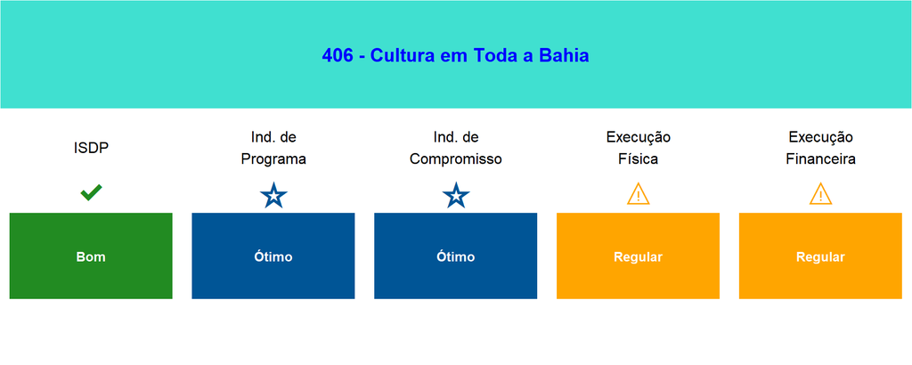

# **2 - Avanços e Conformidades no Programa**

**Indicadores de Programa:** No programa 406 - Cultura em Toda a Bahia, todos os indicadores apresentaram evolução positiva. O indicador 2151, que mede o percentual do estoque de empregos formais na economia criativa em municípios sem faixa litorânea, evoluiu 0,22%. Em 2023, a Bahia registrou 91.889 empregos formais na economia criativa, dos quais 33.451 estavam em municípios sem litoral, cifras que aumentaram em 2024. O apoio financeiro proveniente da Política Nacional Aldir Blanc foi fundamental para esse crescimento. Destaca-se também o indicador 2150, que mede o percentual de empregos formais na economia criativa no interior do estado, com uma evolução de 6,12%, indicando um fortalecimento estruturante do setor e alinhamento com tendências nacionais.  
**Indicadores de Compromisso:** No programa 406 - Cultura em Toda a Bahia, 33,3% dos indicadores de compromisso foram classificados com desempenho bom ou ótimo. Entre eles, destaca-se o indicador ‘1 - Número de municípios com pontos de cultura implantados e recredenciados’, que alcançou 84,67%. Esse resultado pode ser atribuído ao aumento significativo no número de certificações de Pontos e Pontões de Cultura, impulsionado pelas pré-certificações dos novos editais da Política Nacional Aldir Blanc (PNAB) e pelas certificações realizadas diretamente na plataforma do Ministério da Cultura (MinC), totalizando atualmente 1.283 pontos certificados. Contudo, esse crescimento resultou apenas na inclusão de 22 novos municípios. Fatores adicionais que contribuíram para a evolução da meta incluem a realização de oficinas de certificação, o lançamento de cinco editais da PNAB que contemplaram a pré-certificação e diversas ações de mobilização nos territórios. Outro indicador relevante é o ‘2 - Número de escolas integrais com o Projeto Cultura e Educação de Ponto a Ponto implantado’, que obteve 114,29%. Esse desempenho é atribuído ao aporte de recursos orçamentários que favoreceram a execução das ações, além da boa aceitação dos Pontos de Cultura em relação ao projeto, refletindo o elevado interesse e a adesão qualificada dos proponentes. Para 2026, está previsto o lançamento de um novo edital da PNAB, com ajustes que visam facilitar a adesão de novos Pontos de Cultura, especialmente em territórios anteriormente não contemplados, o que gera uma expectativa positiva de ampliação do alcance do projeto e de superação das metas estabelecidas.  
**Ações Orçamentárias:** No Programa 406 - Cultura em Toda a Bahia, 57,2% das ações foram consideradas de bom ou ótimo desempenho na execução financeira, e 64,3% receberam a mesma classificação na execução física. Exemplos incluem a Ação 7987 - Apresentação de Corpo Artístico do Teatro Castro Alves, que teve execução financeira classificada como Boa e execução física como Ótima. A Ação 3160 - Apoio à Territorialização da Cultura obteve classificações de Boa tanto para a execução financeira quanto para a física.

# **3 - Oportunidade de Melhoria no Programa**

**Indicadores de Programa:** No Programa 406 - Cultura em Toda a Bahia, nenhum indicador apresentou evolução negativa.  
**Indicadores de Compromisso:** No programa 406 - Cultura em Toda a Bahia, também não houve indicadores de baixo desempenho. No entanto, 66,7% dos indicadores foram classificados como indeterminados. O indicador ‘2 - Projetos aprovados via Fazcultura’ atingiu 268,9%, superando significativamente a meta devido à aprovação de uma suplementação orçamentária que favoreceu o fomento a projetos culturais. Essa injeção de recursos foi fundamental para atender a várias demandas do setor e ampliou o alcance das políticas públicas culturais.  
**Ações Orçamentárias:** No entanto, no Programa 406 - Cultura em Toda a Bahia, 21,5% das ações foram classificadas com desempenho baixo ou muito baixo na execução financeira, enquanto na execução física esse percentual foi de 28,6%. Exemplos disso são a ação 7984 - Realização de Evento Artístico-Cultural para Formação de Público e Plateia e a ação 7047 - Implantação de Centro de Cultura, que apresentaram desempenho classificado como “Muito Baixo”.

Desenvolvido por: DAP – Diretoria de Avaliação de Políticas Públicas